# Bloque 5

Septiembre, 2017

## Temas

- Qué es MAREA?
- Cómo funciona?
- Qué hace / no hace?
- Demostración
- Ejemplos

## ¿Qué es MAREA?

- Aplicación web (*Beta*): MAREA
- Desarrollada en R, con shiny
  - Permite mezclar `R`, `html`, `JavaScript` y `css`
- Libre acceso
- Se puede ejecutar localmente
- Usa paquete de R MPAtools

## `MPAtools`

- Se puede instalar en R con `devtools::install_github("turfeffect/MPAtools")`
- Contiene todas las funciones necesarias para analizar sin MAREA

```r
natividad <- read.csv("Datos/peces_natividad.csv") %>%
  filter(Ano < 2011) %>%
  MPAtools::shannon(location = "Isla Natividad") %>%
  MPAtools::turfeffect(reserve = "La Plana / Las Cuevas",
                       control = c("La Dulce", "Babencho"),
                       type = "bio",
                       year.imp = 2006)
```

## `MPA tools`

```r
summary(natividad$model)
```

```
##
## Call:
## lm(formula = Indicador ~ Ano + Zona + Post * Zona + Visibilidad +
##     Profundidad, data = data)
##
## Residuals:
##      Min       1Q   Median       3Q      Max
## -1.52715 -0.27148  0.04669  0.36495  1.02932
##
## Coefficients: (2 not defined because of singularities)
##                    Estimate Std. Error t value Pr(>|t|)
## (Intercept)        2.078351   0.142972  14.537  < 2e-16 ***
## Ano2007            0.098062   0.128768   0.762    0.447
## Ano2008            0.060402   0.131138   0.461    0.645
## Ano2009            0.137627   0.124982   1.101    0.272
## Ano2010            0.133012   0.123124   1.080    0.281
## ZonaReserva        0.176596   0.138438   1.276    0.203
## Post1                    NA         NA      NA       NA
## Visibilidad              NA         NA      NA       NA
## Profundidad       -0.041606   0.008299  -5.013 9.61e-07 ***
## ZonaReserva:Post1 -0.158738   0.153193  -1.036    0.301
## ---
## Signif. codes:  0 '***' 0.001 '**' 0.01 '*' 0.05 '.' 0.1 ' ' 1
##
## Residual standard error: 0.4933 on 275 degrees of freedom
## Multiple R-squared:  0.1078, Adjusted R-squared:  0.0851
## F-statistic: 4.747 on 7 and 275 DF,  p-value: 4.712e-05
```

## `MPAtools`

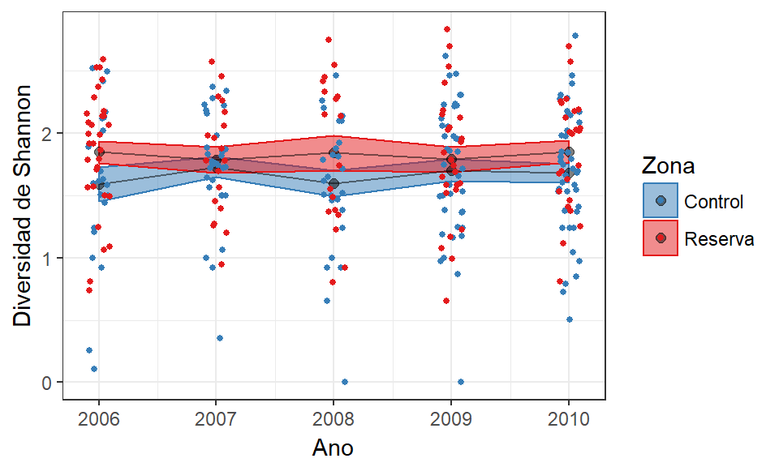

```r
MPAtools::mpa_plot4(model = natividad$model,
                    y.lab = "Diversidad de Shannon")
```

## ¿Qué hace?

- Al indicar objetivos, sugiere indicadores
- Calcula todos los indicadores a partir de datos crudos
  - Identifica algunos errores en datos
  - Incluye historia de vida de **algunas** especies
- Permite evaluar hasta 8 sp objetivo
- Corre hasta 47 modelos simultáneamente (~ 4 segundos total)
- Genera tabla de puntajes
- Genera reporte técnico
- Almacena información del usuario

## ¿Qué **no** hace?

- No provee recomendaciones de manejo
- No limpia datos
- No calcula otros indicadores (pero ya sabemos cómo evaluarlos, y hay paquete de R)
- No reemplaza sentido común ni otros análisis
- No es la única forma de evaluar reservas
- No es la solución absoluta

## ¿Puedo usarlo para AMPs o con otros indicadores?

- AMPs sí, pero la interpretación de los coeficientes es diferente
- Para otros indicadores se puede usar el paquete `MPAtools`

## Su turno

- Descarguen datos en la carpeta de dropbox o de MAREA (turfeffect.shinyapps.io)

| Comunidad | RC | ano |
| --- | --- | --- |
| Puerto Mateo | Gran Reserva - Piedra Patos | 2010 |
|  | Punta Arenas - Punta Focas | 2010 |
| Punta Rompiente | El Arrimadero - Gaviotas | 2013 |
|  | La Rampa - La Rampita | 2013 |
| San Bartolo | Piedra Norte - Piedra Norte (Control) | 2013 |
|  | Piedra Sur - Piedra Sur (Control) | 2013 |

- Datos "inventados"
- Selecciones sus objetivos
- Jueguen con MAREA
- Intenten cometer errores y ver qué pasó

## Futuras mejoras en MAREA

- Mejor identificación de errores en datos
- Generar mapas
- Opción a incluir otros indicadores